# Creating plots from msleep

Cait Kaulens

## Creating our tables for the following graphs. . .

First, for anyone not familiar with this dataset we will take a brief look at the original information.

```
## Rows: 83
## Columns: 11
## $ name         <chr> "Cheetah", "Owl monkey", "Mountain beaver", "Greater shor…
## $ genus        <chr> "Acinonyx", "Aotus", "Aplodontia", "Blarina", "Bos", "Bra…
## $ vore         <chr> "carni", "omni", "herbi", "omni", "herbi", "herbi", "carn…
## $ order        <chr> "Carnivora", "Primates", "Rodentia", "Soricomorpha", "Art…
## $ conservation <chr> "lc", NA, "nt", "lc", "domesticated", NA, "vu", NA, "dome…
## $ sleep_total  <dbl> 12.1, 17.0, 14.4, 14.9, 4.0, 14.4, 8.7, 7.0, 10.1, 3.0, 5…
## $ sleep_rem    <dbl> NA, 1.8, 2.4, 2.3, 0.7, 2.2, 1.4, NA, 2.9, NA, 0.6, 0.8, …
## $ sleep_cycle  <dbl> NA, NA, NA, 0.1333333, 0.6666667, 0.7666667, 0.3833333, N…
## $ awake        <dbl> 11.9, 7.0, 9.6, 9.1, 20.0, 9.6, 15.3, 17.0, 13.9, 21.0, 1…
## $ brainwt      <dbl> NA, 0.01550, NA, 0.00029, 0.42300, NA, NA, NA, 0.07000, 0…
## $ bodywt       <dbl> 50.000, 0.480, 1.350, 0.019, 600.000, 3.850, 20.490, 0.04…
```

I will start by selecting just a few of the columns so I can focus on the size of the animal compared to their diet and sleep patterns. I am also changing the weight measure from kilograms to pounds.

```r
sleep <- msleep %>%
  select(name,vore,awake,sleep_total,bodywt)%>%
  drop_na(vore) %>%
  mutate(wt_lbs = (bodywt * 2.2)) %>%
  arrange(-wt_lbs)
```

## After creating the sleep table,

### we will modify it a bit to show averages of body weight and sleep totals.

```r
gsleep <- sleep %>%
  drop_na(vore) %>%
  group_by(vore) %>%
  summarise(Lower = min(sleep_total),
            Average = mean(sleep_total),
            Upper = max(sleep_total),
            Weight = mean(wt_lbs))%>%
  arrange(Average)
```

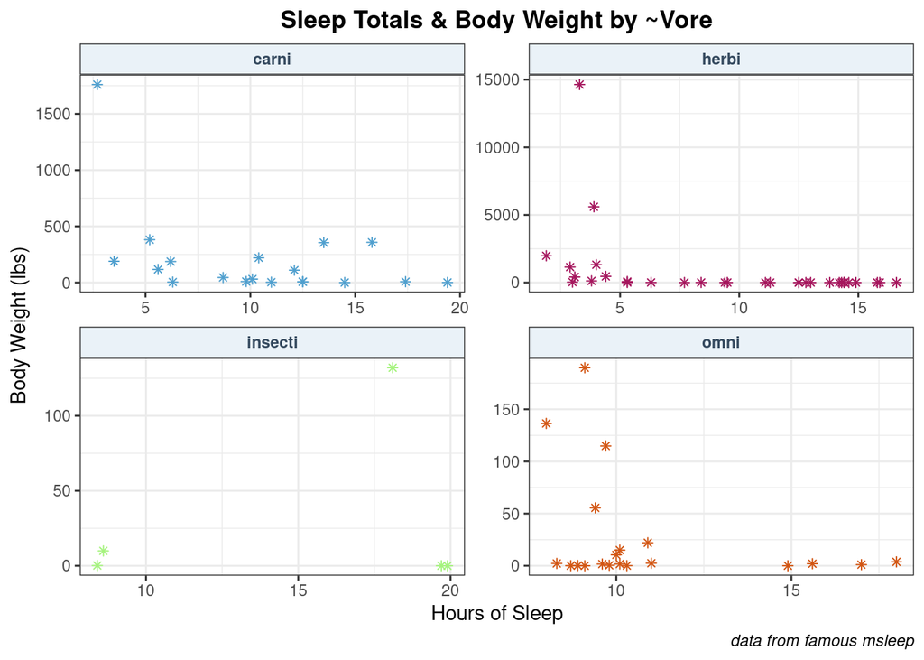

## The next plot

Shows a single point for each our mammal types, representing the average weight of each along with the average hours they spend asleep.

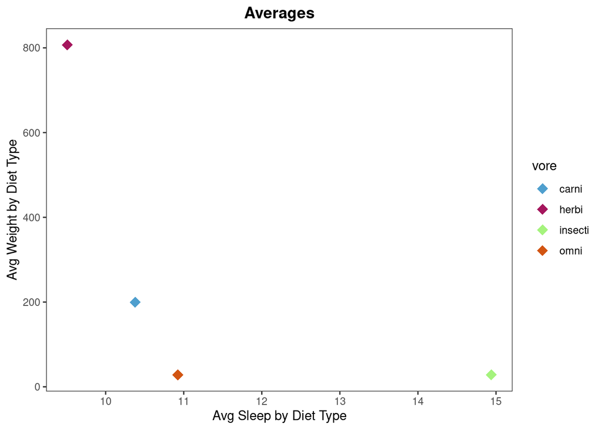

# And then. . .

combining the information into one viz, we can see exactly where the average weight & sleep fall within the individual points.

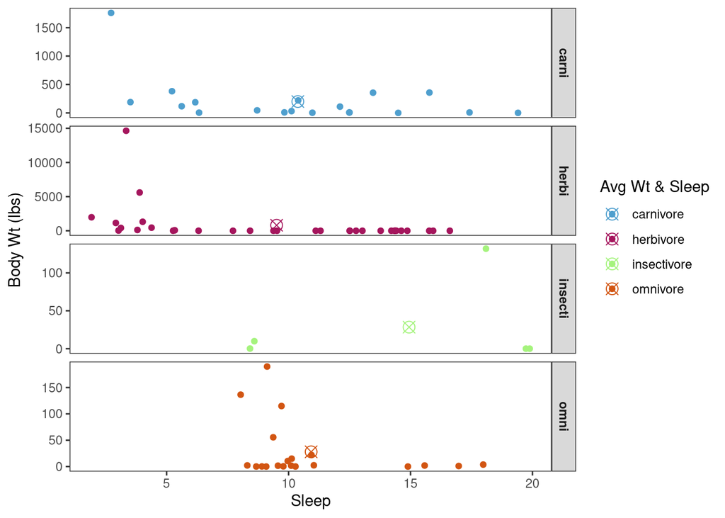

## Let’s have some fun with different types of plots!

I will show the minimum and maximum hours by each diet with a violin plot combined with the individual points by mammal.

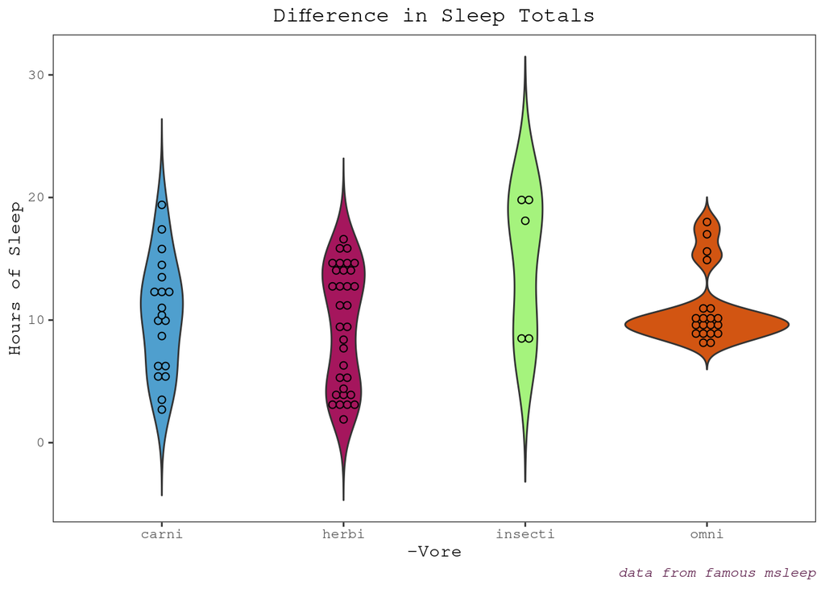

```r
 ggplot(sleep,aes(vore,sleep_total,fill=vore))+
  geom_violin(trim=FALSE,)+
  geom_dotplot(binaxis='y', stackdir='center',
                 position=position_dodge(1))+
  labs(title = "Difference in Sleep Totals",
       caption = "data from famous msleep",
       x= "-Vore",
       y= "Hours of Sleep")+
  scale_fill_manual(values = c("#4F9FCE", "#A5165D","#A5F37D","#D25512"))+
  theme_bw()+
  theme(text = element_text('Courier'),
        plot.title = element_text(hjust = 0.5),
        plot.caption = element_text(face = 'italic',
                                    color = "#581845"),
        panel.grid.major = element_blank(),
        panel.grid.minor = element_blank(),
        legend.position = 'none')
```

Taking a moment to manipulate the data even further. Earlier, I did this step with the time spent asleep. Now I am doing the same for the time spent awake.

```r
gawake <- sleep %>%
  drop_na(vore) %>%
  group_by(vore) %>%
  summarise(Lower = min(awake),
            Average = mean(awake),
            Upper = max(awake),
            Weight = mean(wt_lbs))%>%
  arrange(Average)
```

### Now we can look at the comparison!

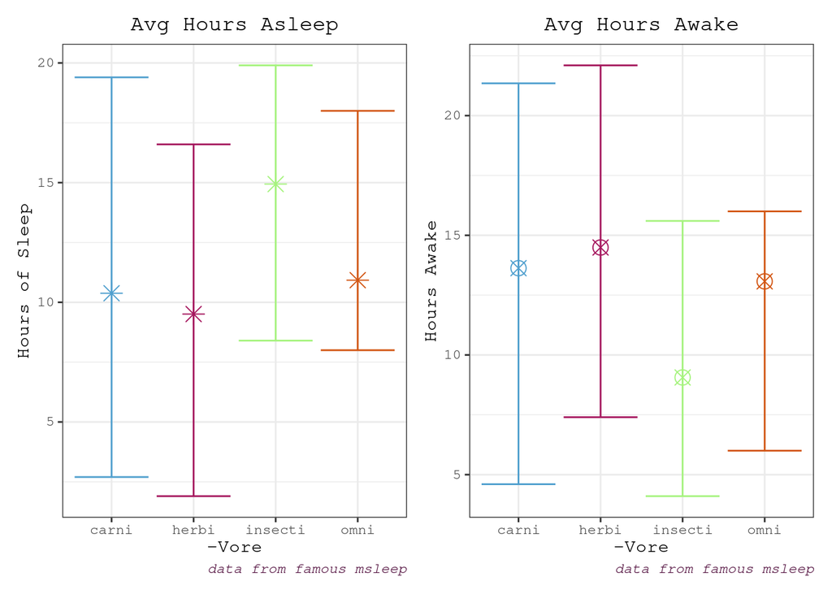

```r
plot1 <- ggplot(MinMax,aes(vore,Average))+
  geom_point(aes(color = vore),
             size = 4,
             shape =8 )+
  geom_errorbar(aes(ymin = Lower, ymax = Upper, color = vore))+
  labs(title = "Avg Hours Asleep",
       caption = "data from famous msleep",
       x= "-Vore",
       y= "Hours of Sleep")+
  scale_color_manual(values = c("#4F9FCE", "#A5165D","#A5F37D","#D25512"))+
  theme_bw()+
  theme(text = element_text('Courier'),
        plot.title = element_text(hjust = 0.5),
        plot.caption = element_text(face = 'italic',
                                    color = "#581845"),
        legend.position = 'none')

plot2 <- ggplot(Awake,aes(vore,Average))+
  geom_point(aes(color = vore),
             size = 4,
             shape =13)+
  geom_errorbar(aes(ymin = Lower, ymax = Upper, color = vore))+
  labs(title = "Avg Hours Awake",
       caption = "data from famous msleep",
       x= "-Vore",
       y= "Hours Awake")+
  scale_color_manual(values = c("#4F9FCE", "#A5165D","#A5F37D","#D25512"))+
  theme_bw()+
  theme(text = element_text('Courier'),
        plot.title = element_text(hjust = 0.5),
        plot.caption = element_text(face = 'italic',
                                    color = "#581845"),
        legend.position = 'none')
```